# Exercice: Exploratory Data Analysis

## By Kalvin Dobler

**1. Import the data:

```r
setwd("C:/Users/Kalvin Edwin/Desktop/Sta Bioinfo/Week3")
```

```r
x <- readRDS("counts.RDS")
pheno <- readRDS("phenodata.RDS")
x_df <- as.data.frame(x)
```

**2. Compute and visualize basic stats:

- How many replicates are there for each combination of factor levels? There 3 technologies: bulk (3 DMSO + 3 TSA), IFC96 (20 DMSO + 20 TSA) and IFC800 (20 DMSO + 20 TSA).

```r
bulk <- pheno$Treatment[which(pheno$Technology == "bulk")]
n_bulkDMSO <- length(grep("DMSO", bulk)) # 3 DMSO
n_bulkTSA <- length(grep("TSA", bulk)) # 3 TSA
ifc96 <- pheno$Treatment[which(pheno$Technology == "IFC96")]
n_ifc96DMSO <- length(grep("DMSO", ifc96)) # 20 DMSO
n_ifc96TSA <- length(grep("TSA", ifc96)) # 20 TSA
ifc800 <- pheno$Treatment[which(pheno$Technology == "IFC800")]
n_ifc800DMSO <- length(grep("DMSO", ifc800)) # 20 DMSO
n_ifc800TSA <- length(grep("TSA", ifc96)) # 20 TSA
```

- How many genes have an expression value above 0 in each sample? There are 21 genes that have expression values higher than 0.

```r
no_zeros <- x_df[apply(x_df!=0, 1, all),]
nrow(no_zeros)
```

```
## [1] 21
```

**3. Normalize the data:

```r
x_df_scaled <- abs(scale(x_df, center = TRUE, scale = FALSE))
```

**4. Transform the data to log-scale:

In order to avoid NaN values I made the scaled values in absolute.

```r
#x_df_scaled = x_df_scaled * 10^6
x_df_logscaled <- log1p(x_df_scaled)
```

**5. Visualize the distribution of the expression values:

Before visualizing the data, I converted it from wide format to long formt using the 'reshape2' package.

However, the results are not the expected ones. I think that another scaling method should be used.

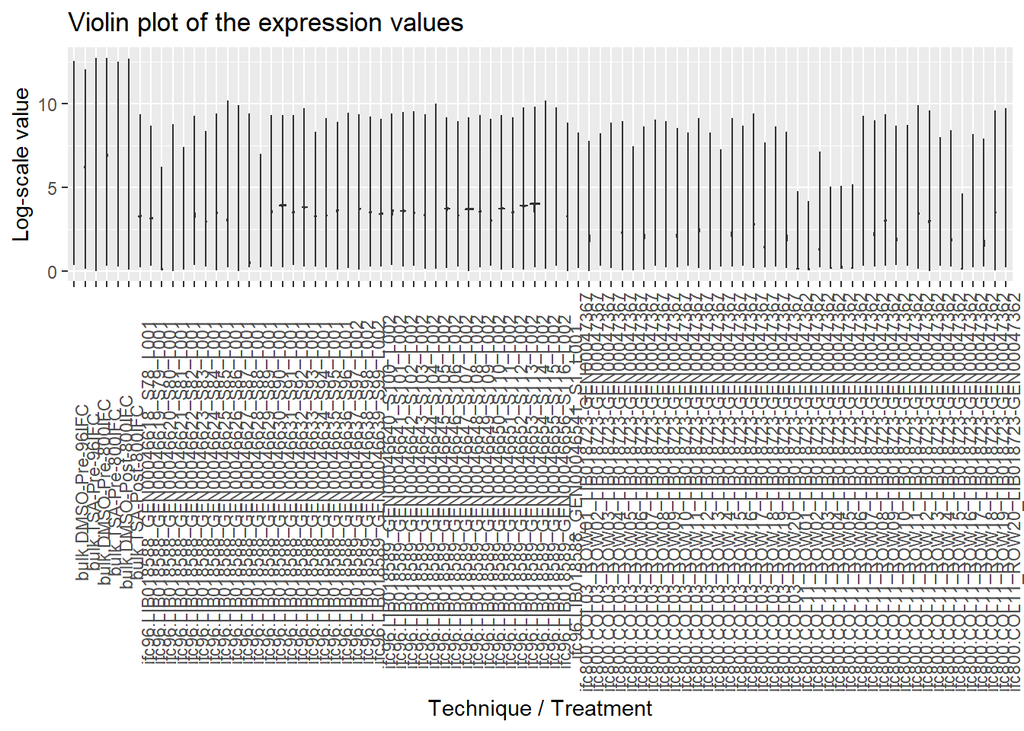

```r
library(reshape2)
library(ggplot2)
x_reshaped <- melt(x_df_logscaled, value.name = "value")
par(mfrow = c(1, 2))

ggplot(x_reshaped, aes(x = x_reshaped$Var2, y = x_reshaped$value, fill = x_reshaped$value)) +
  geom_violin() +
  ggtitle("Violin plot of the expression values") +
  theme(axis.text.x = element_text(angle = 90)) +
  labs(x = "Technique / Treatment", y = "Log-scale value")
```

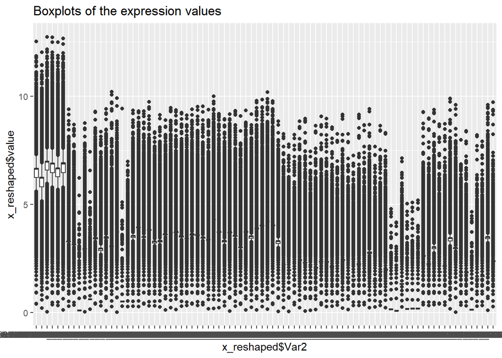

```r
ggplot(x_reshaped, aes(x = x_reshaped$Var2, y = x_reshaped$value)) +
  geom_boxplot() +
  ggtitle("Boxplots of the expression values")
```

```r
  theme(axis.text.x = element_text(angle = 90)) +
  labs(x = "Technique / Treatment", y = "Log-scale value")
```

[output not shown]

**6. Select the most 500 variable genes:

For the sake of clarity, only 20 genes will be displayed. In case one might want to change the number of genes, the modification can be easily done in the third line.

```r
x_df_logscaled <- as.data.frame(x_df_logscaled)
x_df_logscaled$row_var <- apply(x_df_logscaled, 1, var)
sort_test <- x_df_logscaled[order(-x_df_logscaled$row_var),][1:20,1:86]
head(sort_test[1:3,ncol(sort_test)])
```

```
## [1] 2.851359 4.914941 4.950965
```

**7. Compute and visualize the sample-to-sample correlations

The package 'corrplot' allows to better visualize the sample-tosample correlations.

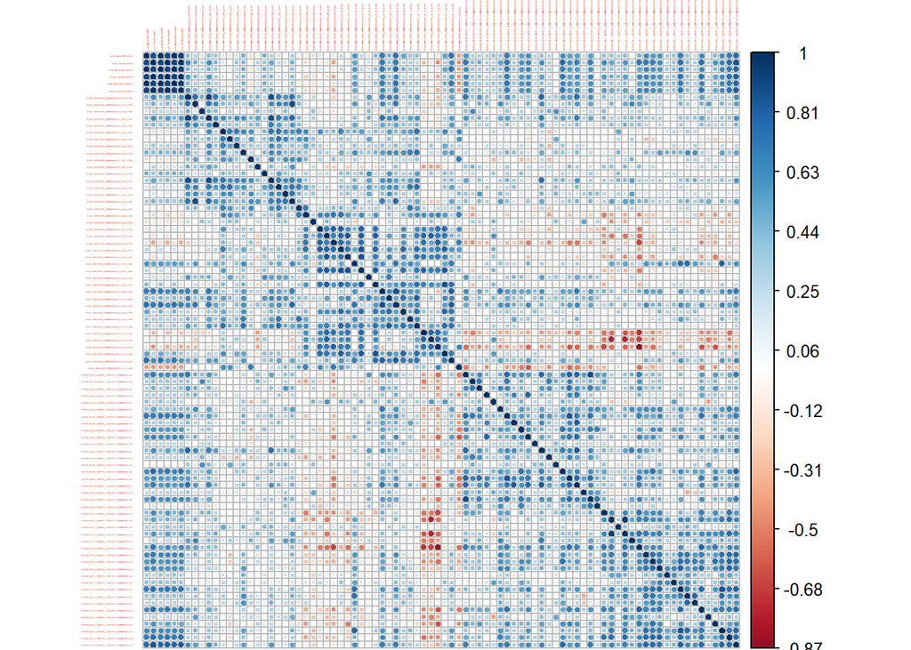

```r
library(corrplot)
fig.dim = c(6, 4)
x_df_cor = cor(sort_test)
corrplot(x_df_cor, is.corr = FALSE, tl.cex = 0.1)
```

I used the euclidean method for constructing the dissimilarity matrix and the average method for constructing the tree.

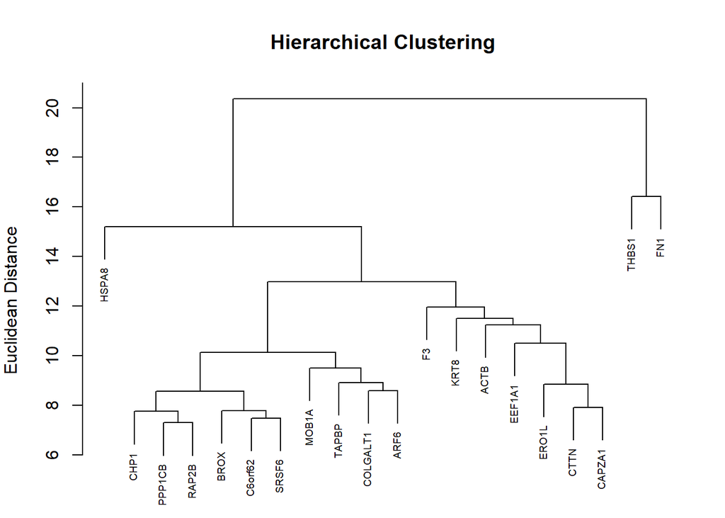

```r
DE <- dist(sort_test, method = "euclidean")
clust <- hclust(DE, method = "average")
#par(cex=0.8)
par(mar=c(0, 4, 4, 2))
plot(clust, ylab = "Euclidean Distance", xlab = ""
     , main = "Hierarchical Clustering",
     cex = 0.6, hang = 0.1,
     sub = "", ylim = c(0, 800))
```

**9. Generate a heatmap of expression values

Finally, the heatmap allows to visualise the relatio between each sample.

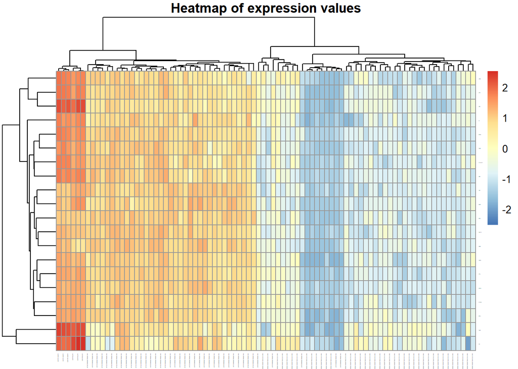

```r
library(pheatmap)
pheatmap(sort_test, main = "Heatmap of expression values",
         fontsize_row = 0.2, fontsize_col = 0.2, scale = "row")
```